# Bayesian modeling and prediction for movies

## Setup

### Load packages

```r
setwd("~/coursera/statistics/bayesian/project")
library(ggplot2)
library(dplyr)
library(statsr)
library(BAS)
```

### Load data

```r
load("movies.Rdata")
```

## Part 1: Data

Even though random sampling was used to create the sample, the origin of the data (rotten tomatoes and IMDB) has the responder bias, as the data is provided by volunteers. So we can’t generalize the conclusions for all population, only to the US population.

As random assignment was not used causality cannot be inferred.

## Part 2: Data manipulation

### Creating feature_film variable

```r
movies <- movies %>%
  mutate(feature_film = factor(ifelse(title_type == 'Feature Film', 'yes', 'no')) )

movies %>%
  select(feature_film) %>%
  summary()
```

```
##  feature_film
##  no : 60
##  yes:591
```

### Creating drama variable

```r
movies <- movies %>%
  mutate(drama = factor(ifelse(genre == 'Drama', 'yes', 'no')) )

movies %>%
  select(drama) %>%
  summary()
```

```
##  drama
##  no :346
##  yes:305
```

### Creating mpaa_rating_R variable

```r
movies <- movies %>%
  mutate(mpaa_rating_R = factor(ifelse(mpaa_rating == 'Unrated', 'no', 'yes')) )

movies %>%
  select(mpaa_rating_R) %>%
  summary()
```

```
##  mpaa_rating_R
##  no : 50
##  yes:601
```

### Creating oscar_season variable

```r
movies <- movies %>%
  mutate(oscar_season = factor(ifelse(thtr_rel_month %in% c(10, 11, 12), 'yes', 'no')) )

movies %>%
  select(oscar_season) %>%
  summary()
```

```
##  oscar_season
##  no :460
##  yes:191
```

### Creating summer_season variable

```r
movies <- movies %>%
  mutate(summer_season = factor(ifelse(thtr_rel_month %in% c(5, 6, 7), 'yes', 'no')) )

movies %>%
  select(summer_season) %>%
  summary()
```

```
##  summer_season
##  no :487
##  yes:164
```

## Part 3: Exploratory data analysis

### Evaluating the relationship of audience_score and feature_film

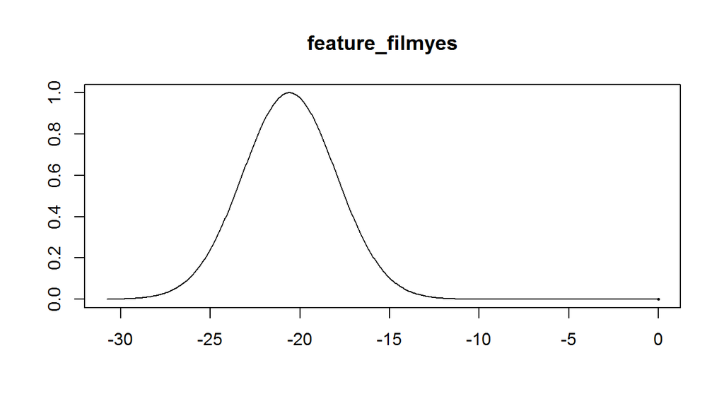

```r
feature_film.bas <- bas.lm(audience_score ~ feature_film,
                    data = movies,
                    prior="BIC",
                    modelprior=Bernoulli(1), bestmodel=rep(1,2),
                    n.models=1)


feature_film.coef=coef(feature_film.bas)
plot(feature_film.coef,subset=2:2, ask=F)
```

As the Bernoulli prior is 1 this variable shows a good predictor to audience_score variable.

### Evaluating the relationship of audience_score and drama

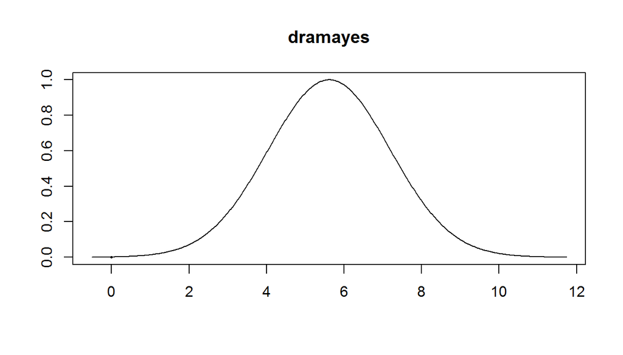

```r
drama.bas <- bas.lm(audience_score ~ drama,
                    data = movies,
                    prior="BIC",
                    modelprior=Bernoulli(1), bestmodel=rep(1,2),
                    n.models=1)


drama.coef=coef(drama.bas)
plot(drama.coef,subset=2:2, ask=F)
```

As the Bernoulli prior is 1 this variable shows a good predictor to audience_score variable.

### Evaluating the relationship of audience_score and mpaa_rating_R

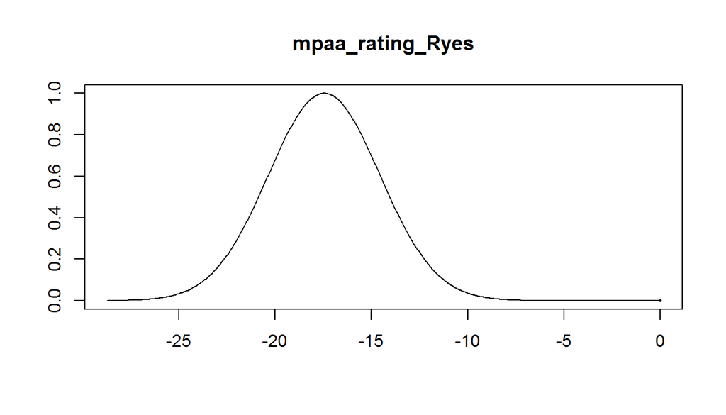

```r
mpaa_rating_R.bas <- bas.lm(audience_score ~ mpaa_rating_R,
                    data = movies,
                    prior="BIC",
                    modelprior=Bernoulli(1), bestmodel=rep(1,2),
                    n.models=1)


mpaa_rating_R.coef=coef(mpaa_rating_R.bas)
plot(mpaa_rating_R.coef,subset=2:2, ask=F)
```

As the Bernoulli prior is 1 this variable shows a good predictor to audience_score variable.

### Evaluating the relationship of audience_score and oscar_season

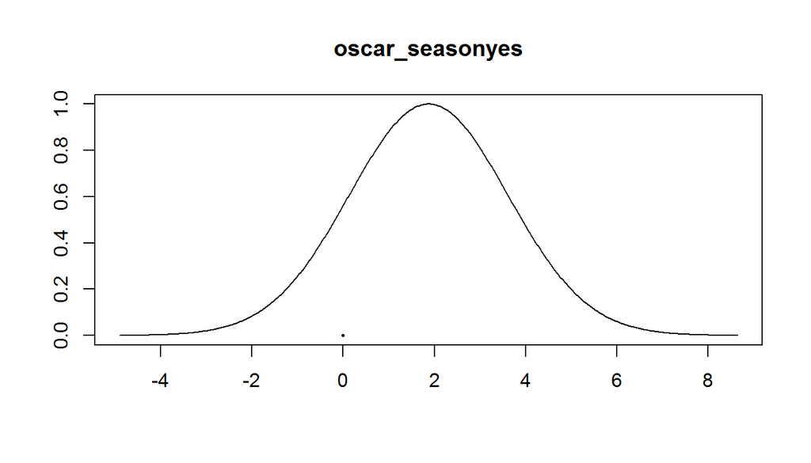

```r
oscar_season.bas <- bas.lm(audience_score ~ oscar_season,
                    data = movies,
                    prior="BIC",
                    modelprior=Bernoulli(1), bestmodel=rep(1,2),
                    n.models=1)


oscar_season.coef = coef(oscar_season.bas)
plot(oscar_season.coef,subset=2:2, ask=F)
```

### Evaluating the relationship of audience_score and summer_season

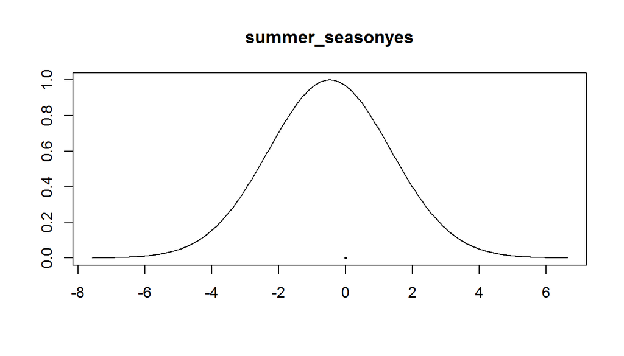

```r
summer_season.bas <- bas.lm(audience_score ~ summer_season,
                    data = movies,
                    prior="BIC",
                    modelprior=Bernoulli(1), bestmodel=rep(1,2),
                    n.models=1)


summer_season.coef = coef(summer_season.bas)
plot(summer_season.coef,subset=2:2, ask=F)
```

## Part 4: Modeling

Let’s build a full model and analyze the BIC best model

```r
variables <- c('Intercept', 'feature_film', 'drama','runtime', 'mpaa_rating_R', 'thtr_rel_year', 'oscar_season', 'summer_season', 'imdb_rating', 'imdb_num_votes', 'critics_score', 'best_pic_nom', 'best_pic_win', 'best_actor_win', 'best_actress_win', 'best_dir_win', 'top200_box')


movies.lm <- lm(audience_score ~ feature_film +  drama +  runtime +  mpaa_rating_R +  thtr_rel_year +  oscar_season +  summer_season +  imdb_rating +  imdb_num_votes +  critics_score +  best_pic_nom +  best_pic_win +  best_actor_win +  best_actress_win +  best_dir_win +  top200_box,
                data = movies)
```

## Using Stepwise to find the best BIC.

As shown in https://github.com/StatsWithR/figures/blob/master/04_bayesian_statistics/week_04/5.3.1_Bayesian_model_selection/R/5.3.1_Bayesian_model_selection.Rmd

```r
n = nrow(movies)
movies.step = step(movies.lm, k=log(n), trace = FALSE)   # penalty for BIC rather than AIC
movies.step
```

```
##
## Call:
## lm(formula = audience_score ~ runtime + imdb_rating + critics_score,
##     data = movies)
##
## Coefficients:
##   (Intercept)        runtime    imdb_rating  critics_score
##     -33.28321       -0.05362       14.98076        0.07036
```

Using stepwise we found `runtime`, `imdb_rating` and `critics_score` as the variables for the best model.

## Using bas.lm to find the best model

```r
movies.bic = bas.lm(audience_score ~ feature_film +  drama +  runtime +  mpaa_rating_R +  thtr_rel_year +  oscar_season +  summer_season +  imdb_rating +  imdb_num_votes +  critics_score +  best_pic_nom +  best_pic_win +  best_actor_win +  best_actress_win +  best_dir_win +  top200_box, data=movies,
                 prior="BIC",
                 modelprior=uniform())
best = which.max(movies.bic$logmarg)  # this is the best BIC model
bestmodel =  movies.bic$which[[best]]
#bestmodel  # indices of the best model where 0 is the intercept
bestgamma = rep(0, movies.bic$n.vars)
# convert to a binary  vector where 1 means the variable was selected
bestgamma[bestmodel + 1] = 1
bestgamma  # use this to fit the best BIC model
```

```
##  [1] 1 0 0 1 0 0 0 0 1 0 1 0 0 0 0 0 0
```

```r
movies.bestbic = bas.lm(audience_score ~ feature_film +  drama +  runtime +  mpaa_rating_R +  thtr_rel_year +  oscar_season +  summer_season +  imdb_rating +  imdb_num_votes +  critics_score +  best_pic_nom +  best_pic_win +  best_actor_win +  best_actress_win +  best_dir_win +  top200_box, data=movies,
                     prior="BIC", n.models=1,
                     bestmodel=bestgamma,
                     modelprior= uniform())
```

After selecting the best model we got the following variables:

```r
variables[bestmodel + 1]
```

```
## [1] "Intercept"     "runtime"       "imdb_rating"   "critics_score"
```

Using Stepwise or BAS we got the same variables (this is nice!).

## Building the final model

Now let’s see the coeficients for this model:

```r
movies.bestbic = bas.lm(audience_score ~ runtime + imdb_rating + critics_score,
                     data=movies,
                     prior = "BIC",
                     modelprior=uniform())
movies.coef = coef(movies.bestbic)

out = confint(movies.coef)
names = c("post mean", "post sd", colnames(out))
movies.bic = cbind(movies.coef$postmean, movies.coef$postsd, out)
colnames(movies.bic) = names
rnames <- rownames(movies.bic)

movies.bic %>%
  as.data.frame() %>%
  mutate(name = rnames) %>%
  select(name, `post mean`, `post sd`, `2.5  %`, `97.5  %`,beta) %>%
  filter (name %in% variables[bestmodel + 1])
```

```
##            name   post mean    post sd      2.5  %    97.5  %        beta
## 1     Intercept 62.34769231 0.39492950 61.58100123 63.1270039 62.34769231
## 2       runtime -0.02755783 0.03092938 -0.08200862  0.0000000 -0.02755783
## 3   imdb_rating 14.96315740 0.72127673 13.66506259 16.5216187 14.96315740
## 4 critics_score  0.06498060 0.02944104  0.00000000  0.1066718  0.06498060
```

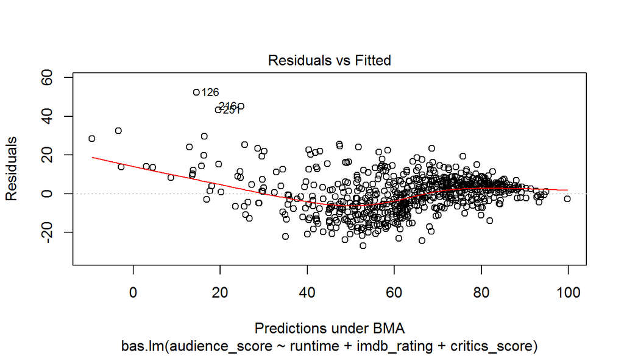

```r
plot(movies.bestbic, which = 1)
```

## Part 5: Prediction

Predicting the 2016 movie [Ben-Hur (2016)](http://www.imdb.com/title/tt2638144/).

```r
new_movie <- data.frame(runtime = 125,
                        imdb_rating = 5.7,
                        critics_score = 4.6,
                        audience_score = as.vector(58))

predicted_score <- predict(movies.bestbic, new_movie, estimator = "BMA", se.fit=TRUE)

as.numeric(predicted_score$fit)
```

```
## [1] 46.52779
```

## Part 6: Conclusion

Using stepwise or BAS to select a model with the lowest BIC value give to us the same results.

When we build the model only with the selected variables we get strange priors.

We can predict a score for a movie outside the range of model but this extrapolation is not recommended.